# Math Department Data Analysis

Cameron Mitchell

23 Sep 2020

The intention of this anaylsis is to try to predict how many students will be in MA132 (Calculus II) in the upcoming year.

Loading packages

```r
library(tidyverse)
library(janitor)
library(readxl)
library(skimr)
library(summarytools)
```

Reading the data from an excel file that is stored in the data folder.

```r
dfa = read_excel("../Data/CU_ACAD_DEPT_ENRL.xls") %>%
clean_names()
```

Quick summary of the data available

```r
skim(dfa)
```

```
-- Data Summary ------------------------
                           Values
Name                       dfa
Number of rows             3343
Number of columns          12
_______________________
Column type frequency:
  character                11
  numeric                  1
________________________
Group variables            None

-- Variable type: character ----------------------------------------------------------------------------------------------------------------------------
# A tibble: 11 x 8
   skim_variable  n_missing complete_rate   min   max empty n_unique whitespace
 * <chr>              <int>         <dbl> <int> <int> <int>    <int>      <int>
 1 acad_org               0             1     5     5     0        1          0
 2 current_status         0             1     6     6     0        1          0
 3 course_id              0             1     6     6     0       88          0
 4 subject                0             1     2     4     0        4          0
 5 catalog                0             1     2     3     0       85          0
 6 section                0             1     1     4     0       84          0
 7 term                   0             1     4     4     0       21          0
 8 term2                  0             1     9    11     0       21          0
 9 title                  0             1    10    30     0       81          0
10 component              0             1     3     3     0        7          0
11 instructor             0             1     6    50     0      250          0

-- Variable type: numeric ------------------------------------------------------------------------------------------------------------------------------
# A tibble: 1 x 11
  skim_variable n_missing complete_rate  mean    sd    p0   p25   p50   p75  p100 hist
* <chr>             <int>         <dbl> <dbl> <dbl> <dbl> <dbl> <dbl> <dbl> <dbl> <chr>
1 tot_enrl              0             1  20.7  22.5     0     3    17    26   137 ▇▁▁▁▁
```

Tidying the data

```r
dfb = dfa %>%
  separate(col = term2, into = c("semester","year"), sep = " ")
```

Cleaning and organizing the data that is required to complete this analysis

dfc1 will contain the data for calculus 1 and dfc2 will contain the data from calculus 2.

```r
# dfc1 = dfb %>%
#   select(-c(section, term, acad_org,current_status,instructor,course_id)) %>%
#   filter(title == "Calculus I", component == "LEC", year < 2021) %>%
#   unique()

dfc2 = dfb %>%
  select(-c(section, term, acad_org,current_status,course_id)) %>%
  filter(title == "Calculus II", component == "LEC", year < 2021) %>%
  unique() %>%
  group_by(title, semester, year)
summarise(dfc2, tot_enrl = sum(tot_enrl))
```

| title | semester | year | tot_enrl |
| --- | --- | --- | --- |
| Calculus II | Fall | 2014 | 136 |
| Calculus II | Fall | 2015 | 165 |
| Calculus II | Fall | 2016 | 191 |
| Calculus II | Fall | 2017 | 155 |
| Calculus II | Fall | 2018 | 172 |
| Calculus II | Fall | 2019 | 169 |
| Calculus II | Fall | 2020 | 156 |
| Calculus II | Spring | 2015 | 436 |
| Calculus II | Spring | 2016 | 460 |
| Calculus II | Spring | 2017 | 337 |

[output cut: 10 more lines]

Lets try to see if there are any trends we can see any trends with the data that we have.

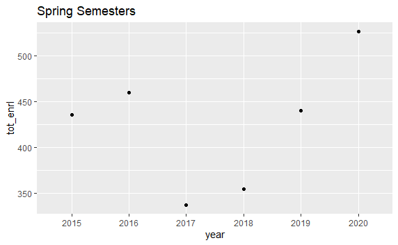

```r
dfc2 %>%
  filter(semester == "Spring") %>%
  group_by(year) %>%
  summarise(tot_enrl = sum(tot_enrl)) %>%
  ggplot(aes(x = year, y = tot_enrl)) + geom_point() + ggtitle("Spring Semesters")
```

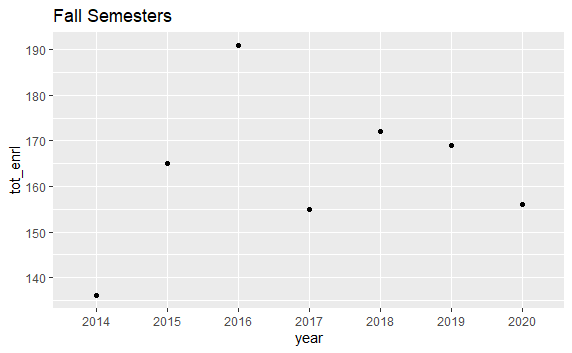

```r
dfc2 %>%
  filter(semester == "Fall") %>%
  group_by(year) %>%
  summarise(tot_enrl = sum(tot_enrl)) %>%
  ggplot(aes(x = year, y = tot_enrl)) + geom_point() + ggtitle("Fall Semesters")
```

It seems as if there is no general increase or decrease of enrollment over this span of time.

I do not believe that looking at the professors will help solve the question of how many students will enroll in a math course but out of my own curiosity I am going to investigate it.

```r
dfteacher = dfc2 %>%
  group_by(instructor) %>%
  summarise(tot_enrl = sum(tot_enrl))
dfteacher[order(-dfteacher$tot_enrl),]
```

| instructor | tot_enrl |
| --- | --- |
| Martin,Christopher J. | 1004 |
| Kavanagh,Kathleen R | 828 |
| Morrison,Sara A. | 562 |
| Almomani,Ahmad Rasheed | 230 |
| White,Diana Terese | 189 |
| Yao,Guangming | 177 |
| Appleton,Jay | 158 |
| Parshad,Rana D | 133 |
| Song,Guohui | 123 |
| Athavale,Prashant Vinayak | 87 |

[output cut: 5 more lines]

I do not believe there is enough relevant data here to accurately predict how many students will be enrolled in the next year.